# Titanic survival prediction

## Titanic Survival Prediction:

To predict the possibility of a passenger surviving on the Titanic dataset.

## 1. Importing the packages and libraries

```python
# Data wrangling
import pandas as pd
import numpy as np
from collections import Counter

# Data visualisation
import seaborn as sns
import matplotlib.pyplot as plt

# Machine learning models
from sklearn.ensemble import RandomForestClassifier
from sklearn.tree import DecisionTreeClassifier
from sklearn.metrics import accuracy_score

# Remove warnings
import warnings
warnings.filterwarnings('ignore')
```

## 2. Import and read the datasets

```python
test = pd.read_csv(r'C:\Users\HARITHA\Desktop\titanic\test.csv')
train = pd.read_csv(r'C:\Users\HARITHA\Desktop\titanic\train.csv')
```

```python
#lets take a look at our test data
test.head()
```

|  | PassengerId | Pclass | Name | Sex | Age | SibSp | Parch | Ticket | Fare | Cabin | Embarked |
| --- | --- | --- | --- | --- | --- | --- | --- | --- | --- | --- | --- |
| 0 | 892 | 3 | Kelly, Mr. James | male | 34.5 | 0 | 0 | 330911 | 7.8292 | NaN | Q |
| 1 | 893 | 3 | Wilkes, Mrs. James (Ellen Needs) | female | 47.0 | 1 | 0 | 363272 | 7.0000 | NaN | S |
| 2 | 894 | 2 | Myles, Mr. Thomas Francis | male | 62.0 | 0 | 0 | 240276 | 9.6875 | NaN | Q |
| 3 | 895 | 3 | Wirz, Mr. Albert | male | 27.0 | 0 | 0 | 315154 | 8.6625 | NaN | S |
| 4 | 896 | 3 | Hirvonen, Mrs. Alexander (Helga E Lindqvist) | female | 22.0 | 1 | 1 | 3101298 | 12.2875 | NaN | S |

```python
# Now the train data
train.head()
```

|  | PassengerId | Survived | Pclass | Name | Sex | Age | SibSp | Parch | Ticket | Fare | Cabin | Embarked |
| --- | --- | --- | --- | --- | --- | --- | --- | --- | --- | --- | --- | --- |
| 0 | 1 | 0 | 3 | Braund, Mr. Owen Harris | male | 22.0 | 1 | 0 | A/5 21171 | 7.2500 | NaN | S |
| 1 | 2 | 1 | 1 | Cumings, Mrs. John Bradley (Florence Briggs Th... | female | 38.0 | 1 | 0 | PC 17599 | 71.2833 | C85 | C |
| 2 | 3 | 1 | 3 | Heikkinen, Miss. Laina | female | 26.0 | 0 | 0 | STON/O2. 3101282 | 7.9250 | NaN | S |
| 3 | 4 | 1 | 1 | Futrelle, Mrs. Jacques Heath (Lily May Peel) | female | 35.0 | 1 | 0 | 113803 | 53.1000 | C123 | S |
| 4 | 5 | 0 | 3 | Allen, Mr. William Henry | male | 35.0 | 0 | 0 | 373450 | 8.0500 | NaN | S |

```python
test.shape
```

```
(418, 11)
```

```python
train.shape
```

```
(891, 12)
```

## 3. Data description:

Below are the description of the features in the data:

- Survival: 0 = Did not survive, 1 = Survived
- Pclass: Ticket class where 1 = First class, 2 = Second class, 3 = Third class. This can also be seen as a proxy for socio-economic status.
- Sex: Male or female
- Age: Age in years, fractional if less than 1
- SibSp: Number of siblings or spouses aboard the titanic
- Parch: Number of parents or children aboard the titanic
- Ticket: Passenger ticket number
- Fare: Passenger fare
- Cabin: Cabin number
- Embarked: Point of embarkation where C = Cherbourg, Q = Queenstown, S = Southampton

## 4. Exploratory Data Analysis (EDA)

Exploratory data analysis is the process of visualising and analysing data to extract insights. In other words, we want to summarise important characteristics and trends in our data in order to gain a better understanding of our dataset.

### 4.1 Data types, missing data and summary statistics

```python
# Non-null count and data types of the train and test dataset

train.info()

print('-'*40)

test.info()
```

```
<class 'pandas.core.frame.DataFrame'>
RangeIndex: 891 entries, 0 to 890
Data columns (total 12 columns):
 #   Column       Non-Null Count  Dtype
---  ------       --------------  -----
 0   PassengerId  891 non-null    int64
 1   Survived     891 non-null    int64
 2   Pclass       891 non-null    int64
 3   Name         891 non-null    object
 4   Sex          891 non-null    object
 5   Age          714 non-null    float64
 6   SibSp        891 non-null    int64
 7   Parch        891 non-null    int64
 8   Ticket       891 non-null    object
 9   Fare         891 non-null    float64
 10  Cabin        204 non-null    object
 11  Embarked     889 non-null    object
dtypes: float64(2), int64(5), object(5)
memory usage: 83.7+ KB
----------------------------------------
<class 'pandas.core.frame.DataFrame'>
RangeIndex: 418 entries, 0 to 417
Data columns (total 11 columns):
 #   Column       Non-Null Count  Dtype
---  ------       --------------  -----
 0   PassengerId  418 non-null    int64
 1   Pclass       418 non-null    int64
 2   Name         418 non-null    object
 3   Sex          418 non-null    object
 4   Age          332 non-null    float64
 5   SibSp        418 non-null    int64
 6   Parch        418 non-null    int64
 7   Ticket       418 non-null    object
 8   Fare         417 non-null    float64
 9   Cabin        91 non-null     object
 10  Embarked     418 non-null    object
dtypes: float64(2), int64(4), object(5)
memory usage: 36.1+ KB
```

```python
# Missing data in train dataset by columns

train.isnull().sum().sort_values(ascending=False) # sort values by descending order
```

```
Cabin          687
Age            177
Embarked         2
PassengerId      0
Survived         0
Pclass           0
Name             0
Sex              0
SibSp            0
Parch            0
Ticket           0
Fare             0
dtype: int64
```

```python
# Missing data in test dataset by columns

test.isnull().sum().sort_values(ascending = False)  # sort values by descending order
```

```
Cabin          327
Age             86
Fare             1
PassengerId      0
Pclass           0
Name             0
Sex              0
SibSp            0
Parch            0
Ticket           0
Embarked         0
dtype: int64
```

- Seems like Age, Cabin and Embarked colummns in the train dataset have missing data
- while Age, Fare and Cabin in the test dataset have missing data.

```python
# Summary statistics for train dataset

train.describe()
```

|  | PassengerId | Survived | Pclass | Age | SibSp | Parch | Fare |
| --- | --- | --- | --- | --- | --- | --- | --- |
| count | 891.000000 | 891.000000 | 891.000000 | 714.000000 | 891.000000 | 891.000000 | 891.000000 |
| mean | 446.000000 | 0.383838 | 2.308642 | 29.699118 | 0.523008 | 0.381594 | 32.204208 |
| std | 257.353842 | 0.486592 | 0.836071 | 14.526497 | 1.102743 | 0.806057 | 49.693429 |
| min | 1.000000 | 0.000000 | 1.000000 | 0.420000 | 0.000000 | 0.000000 | 0.000000 |
| 25% | 223.500000 | 0.000000 | 2.000000 | 20.125000 | 0.000000 | 0.000000 | 7.910400 |
| 50% | 446.000000 | 0.000000 | 3.000000 | 28.000000 | 0.000000 | 0.000000 | 14.454200 |
| 75% | 668.500000 | 1.000000 | 3.000000 | 38.000000 | 1.000000 | 0.000000 | 31.000000 |
| max | 891.000000 | 1.000000 | 3.000000 | 80.000000 | 8.000000 | 6.000000 | 512.329200 |

```python
# Summary statistics for test dataset

test.describe()
```

|  | PassengerId | Pclass | Age | SibSp | Parch | Fare |
| --- | --- | --- | --- | --- | --- | --- |
| count | 418.000000 | 418.000000 | 332.000000 | 418.000000 | 418.000000 | 417.000000 |
| mean | 1100.500000 | 2.265550 | 30.272590 | 0.447368 | 0.392344 | 35.627188 |
| std | 120.810458 | 0.841838 | 14.181209 | 0.896760 | 0.981429 | 55.907576 |
| min | 892.000000 | 1.000000 | 0.170000 | 0.000000 | 0.000000 | 0.000000 |
| 25% | 996.250000 | 1.000000 | 21.000000 | 0.000000 | 0.000000 | 7.895800 |
| 50% | 1100.500000 | 3.000000 | 27.000000 | 0.000000 | 0.000000 | 14.454200 |
| 75% | 1204.750000 | 3.000000 | 39.000000 | 1.000000 | 0.000000 | 31.500000 |
| max | 1309.000000 | 3.000000 | 76.000000 | 8.000000 | 9.000000 | 512.329200 |

### 4.2 Feature analysis

In this next section of the notebook, we will analyse the features in our dataset individually and see how they correlate with survival probability.

### 4.2.1 Categorical variables in our dataset are

- Sex
- Pclass
- Embarked.

### Analysis of Categorical variable: Sex

```python
# Value counts of the sex column

train['Sex'].value_counts(dropna = False)

# Comment: There are more male passengers than female passengers on titanic
```

```
Sex
male      577
female    314
Name: count, dtype: int64
```

```python
# Mean of survival grouped by sex

train[['Sex','Survived']].groupby('Sex', as_index = False).mean().sort_values(by = 'Survived', ascending = False)
```

|  | Sex | Survived |
| --- | --- | --- |
| 0 | female | 0.742038 |
| 1 | male | 0.188908 |

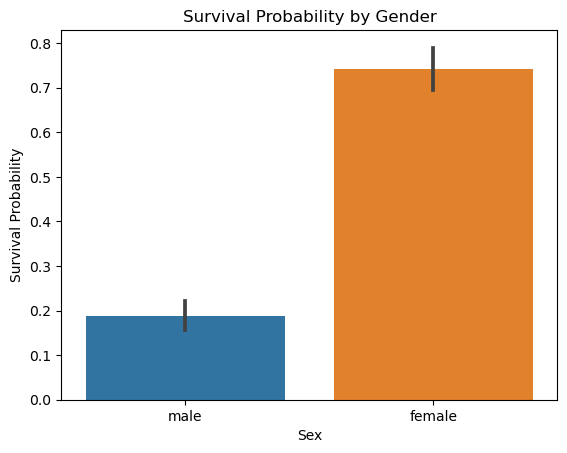

```python
sns.barplot(x = 'Sex',y = 'Survived',data = train)
plt.ylabel('Survival Probability')
plt.title("Survival Probability by Gender")
plt.show()
```

##### From the above chart is Female passengers are more likely to survive

### Analysis of Categorical variable: Passenger class

```python
# Value counts of the  passenger class column

train['Pclass'].value_counts(dropna=False)
```

```
Pclass
3    491
1    216
2    184
Name: count, dtype: int64
```

```python
# Mean of survival by passenger class

train[['Pclass','Survived']].groupby('Pclass',as_index=False).mean().sort_values(by='Pclass',ascending=True)
```

|  | Pclass | Survived |
| --- | --- | --- |
| 0 | 1 | 0.629630 |
| 1 | 2 | 0.472826 |
| 2 | 3 | 0.242363 |

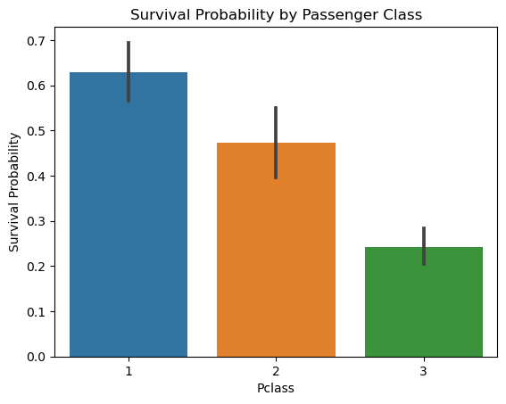

```python
sns.barplot(x='Pclass',y='Survived',data=train)
plt.ylabel('Survival Probability')
plt.title('Survival Probability by Passenger Class')
plt.show()
```

##### From the above chart Survival probability decrease with passenger class, first class passengers are prioritised during evacuation

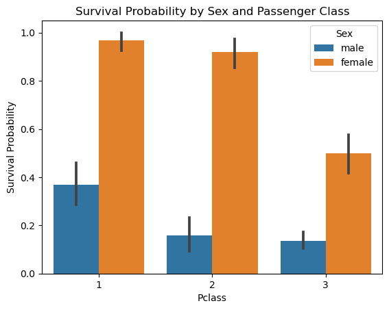

```python
sns.barplot(x = 'Pclass', y = 'Survived', hue = 'Sex', data = train)
plt.ylabel('Survival Probability')
plt.title('Survival Probability by Sex and Passenger Class')
plt.show()
```

### Analysis of Categorical variable: Embarked

```python
# Value counts of the Embarked column

train['Embarked'].value_counts(dropna = False)

# Comment: Two missing values in the Embarked column
```

```
Embarked
S      644
C      168
Q       77
NaN      2
Name: count, dtype: int64
```

```python
# Mean of survival by point of embarkation

train[['Embarked', 'Survived']].groupby(['Embarked'], as_index = False).mean().sort_values(by = 'Survived', ascending = False)
```

|  | Embarked | Survived |
| --- | --- | --- |
| 0 | C | 0.553571 |
| 1 | Q | 0.389610 |
| 2 | S | 0.336957 |

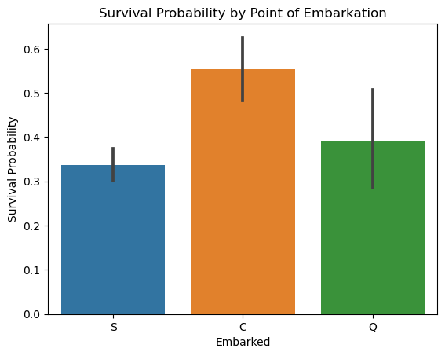

```python
sns.barplot(x = 'Embarked', y ='Survived', data = train)
plt.ylabel('Survival Probability')
plt.title('Survival Probability by Point of Embarkation')
plt.show()
```

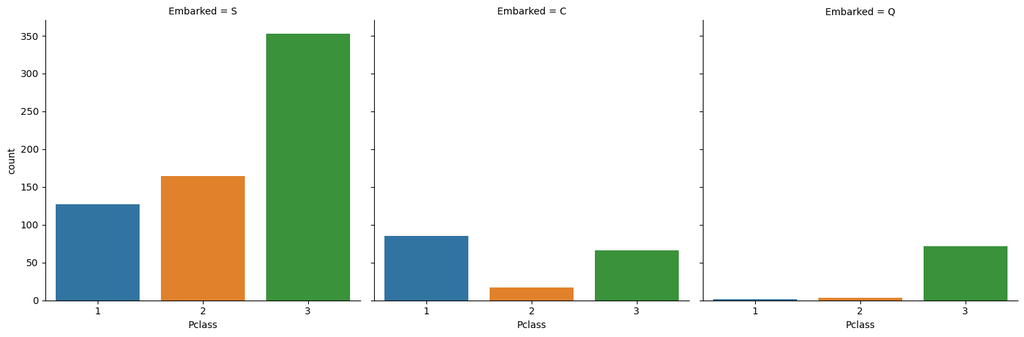

```python
sns.catplot(data=train, x= 'Pclass', col = 'Embarked', kind = 'count')
```

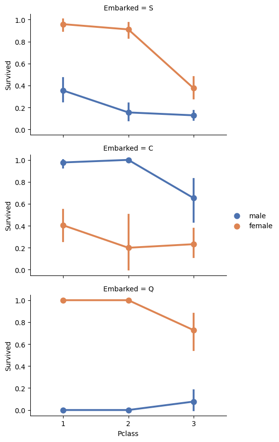

```python
# Survival probability by all categorical variables

grid = sns.FacetGrid(train, row = 'Embarked', aspect = 1.6)
grid.map(sns.pointplot, 'Pclass', 'Survived', 'Sex', palette = 'deep')
grid.add_legend()
plt.show()
# A point plot represents an estimate of central tendency for a numeric variable by the position of the dot
# and provides some indication of the uncertainty around that estimate using error bars.
```

### 4.2.2 Numerical variables in our datasets are

- SibSp
- Parch
- Age
- Fare

### Detect and impute outliers in numerical variables

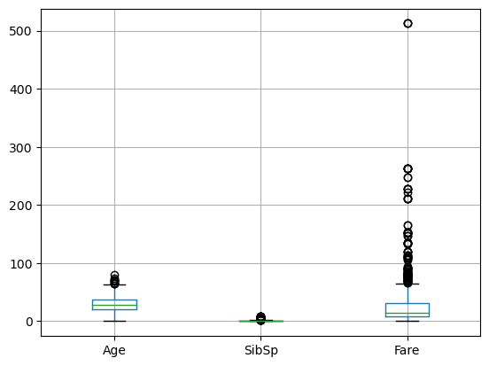

```python
x = train[['Age','SibSp','Fare']]
x.boxplot()
plt.show()
```

```python
## make a copy of the dataframe
dfc = train[['Age','SibSp','Fare']]

## Include only numeric columns
dfc_2 = dfc.select_dtypes(include=np.number)

## Calculate IQR
Q1 = dfc_2.quantile(0.25)
Q3 = dfc_2.quantile(0.75)
IQR = Q3-Q1

ll = Q1-(1.5*IQR)
UL = Q3+(1.5*IQR)
```

```python
# Replace every outlier on the lower side by the lower whisker
dfc_2 = pd.DataFrame(np.where(dfc_2>UL,UL,dfc_2),columns=dfc_2.columns)

# Replace every outlier on the upper side by the upper whisker
dfc_2 = pd.DataFrame(np.where(dfc_2<ll,ll,dfc_2),columns=dfc_2.columns)
```

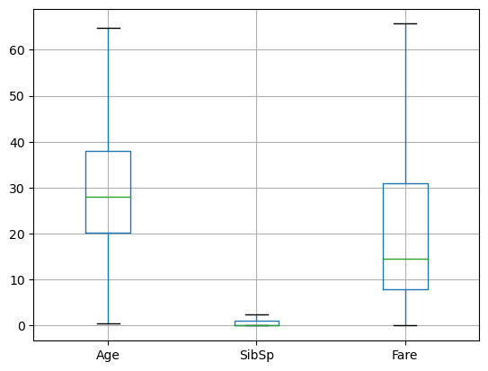

```python
dfc_2.boxplot()
plt.show()
```

```python
train['Age']=dfc_2['Age']
```

```python
train['SibSp']=dfc_2['SibSp']
```

```python
train['Fare']=dfc_2['Fare']
```

### Numerical variables correlation with survival

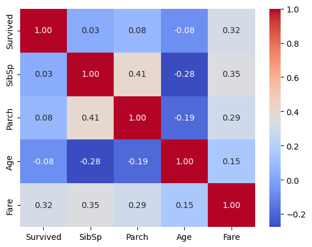

```python
sns.heatmap(train[['Survived', 'SibSp', 'Parch', 'Age', 'Fare']].corr(),annot = True, fmt = '.2f', cmap = 'coolwarm')
plt.show()
```

### Numerical variable: SibSp

```python
# Value counts of the SibSp column
train['SibSp'].value_counts(dropna = False)
```

```
SibSp
0.0    608
1.0    209
2.5     46
2.0     28
Name: count, dtype: int64
```

```python
# Mean of survival by SibSp
train[['SibSp','Survived']].groupby('SibSp',as_index=False).mean().sort_values(by = 'Survived', ascending = False)
```

|  | SibSp | Survived |
| --- | --- | --- |
| 1 | 1.0 | 0.535885 |
| 2 | 2.0 | 0.464286 |
| 0 | 0.0 | 0.345395 |
| 3 | 2.5 | 0.152174 |

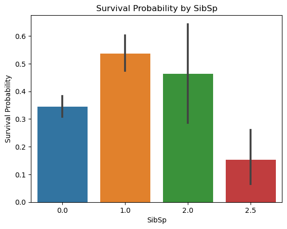

```python
sns.barplot(x='SibSp',y='Survived',data=train)
plt.ylabel('Survival Probability')
plt.title('Survival Probability by SibSp')
plt.show()
```

## Numerical variable: Parch

```python
# Value counts of the Parch column
train['Parch'].value_counts(dropna=False)
```

```
Parch
0    678
1    118
2     80
5      5
3      5
4      4
6      1
Name: count, dtype: int64
```

```python
# Mean of survival by Parch
train[['Parch', 'Survived']].groupby('Parch', as_index = False).mean().sort_values(by = 'Survived', ascending = False)
```

|  | Parch | Survived |
| --- | --- | --- |
| 3 | 3 | 0.600000 |
| 1 | 1 | 0.550847 |
| 2 | 2 | 0.500000 |
| 0 | 0 | 0.343658 |
| 5 | 5 | 0.200000 |
| 4 | 4 | 0.000000 |
| 6 | 6 | 0.000000 |

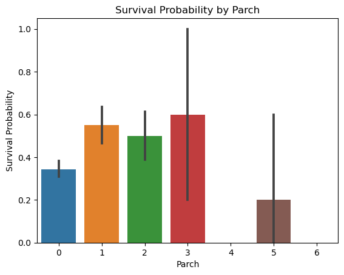

```python
sns.barplot(x='Parch',y='Survived',data=train)
plt.ylabel('Survival Probability')
plt.title('Survival Probability by Parch')
plt.show()
```

### Numerical variable: Age

```python
# Null values in Age column

train['Age'].isnull().sum()
```

```
177
```

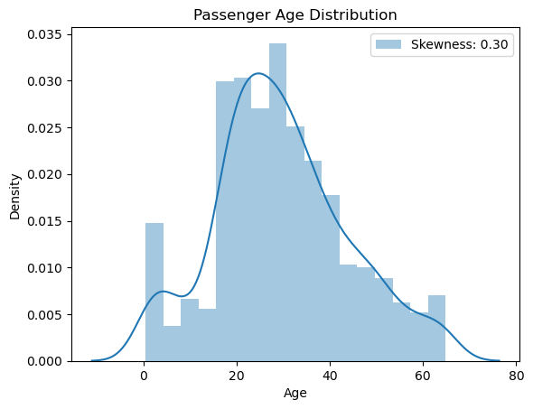

```python
sns.distplot(train['Age'], label = 'Skewness: %.2f'%(train['Age'].skew()))
plt.legend(loc = 'best')
plt.title('Passenger Age Distribution')
plt.show()
```

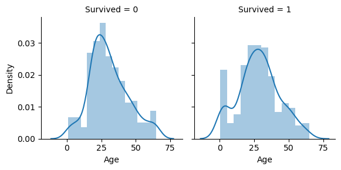

```python
# Age distribution by survival

g = sns.FacetGrid(train, col = 'Survived')
g.map(sns.distplot, 'Age')
```

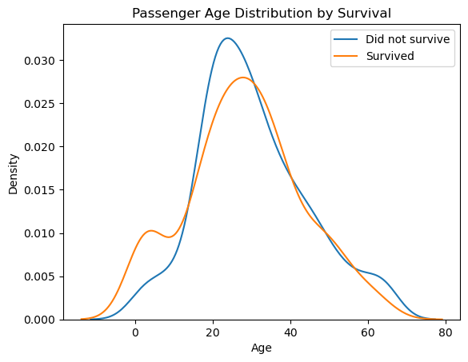

```python
sns.kdeplot(train['Age'][train['Survived'] == 0], label = 'Did not survive')
sns.kdeplot(train['Age'][train['Survived'] == 1], label = 'Survived')
plt.legend(loc='best')
plt.xlabel('Age')
plt.title('Passenger Age Distribution by Survival')
plt.show()
```

### Numerical variable: Fare

```python
# Null values of Fare column

train['Fare'].isnull().sum()
```

```
0
```

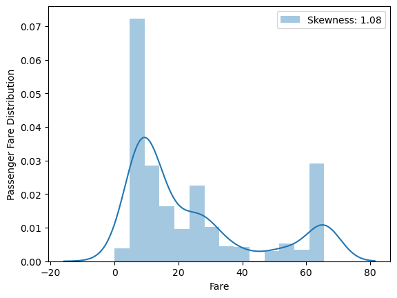

```python
# Passenger fare distribution

sns.distplot(train['Fare'], label = 'Skewness: %.2f'%(train['Fare'].skew()))
plt.legend(loc = 'best')
plt.ylabel('Passenger Fare Distribution')
```

#### Fare seems to have a high skewness. We will address this issue later on in the notebook via log transformation.

## 5. Data preprocessing

Data preprocessing is the process of getting our dataset ready for model training. In this section, we will perform the following preprocessing steps:

- Drop and fill missing values
- Data trasformation (log transformation)
- Feature engineering
- Feature encoding

### 5.1 Drop and fill missing values

```python
# Drop ticket and cabin features from train and test dataset

train = train.drop(['Ticket', 'Cabin'], axis = 1)
test = test.drop(['Ticket', 'Cabin'], axis = 1)
```

```python
# Missing values in train dataset

train.isnull().sum().sort_values(ascending = False)
```

```
Age            177
Embarked         2
PassengerId      0
Survived         0
Pclass           0
Name             0
Sex              0
SibSp            0
Parch            0
Fare             0
dtype: int64
```

```python
# Compute the most frequent value of Embarked in training set

mode = train['Embarked'].dropna().mode()[0]
mode
```

```
'S'
```

```python
# Fill missing value in Embarked with mode

train['Embarked'].fillna(mode, inplace = True)
```

```python
# Missing values in test set

test.isnull().sum().sort_values(ascending = False)
```

```
Age            86
Fare            1
PassengerId     0
Pclass          0
Name            0
Sex             0
SibSp           0
Parch           0
Embarked        0
dtype: int64
```

```python
# Compute median of Fare in test set

median = test['Fare'].dropna().median()
median
```

```
14.4542
```

```python
# Fill missing value in Fare with median

test['Fare'].fillna(median, inplace = True)
```

```python
# Combine training set and test set

combined = pd.concat([train, test], axis = 0).reset_index(drop = True)
combined.head()
```

|  | PassengerId | Survived | Pclass | Name | Sex | Age | SibSp | Parch | Fare | Embarked |
| --- | --- | --- | --- | --- | --- | --- | --- | --- | --- | --- |
| 0 | 1 | 0.0 | 3 | Braund, Mr. Owen Harris | male | 22.0 | 1.0 | 0 | 7.2500 | S |
| 1 | 2 | 1.0 | 1 | Cumings, Mrs. John Bradley (Florence Briggs Th... | female | 38.0 | 1.0 | 0 | 65.6344 | C |
| 2 | 3 | 1.0 | 3 | Heikkinen, Miss. Laina | female | 26.0 | 0.0 | 0 | 7.9250 | S |
| 3 | 4 | 1.0 | 1 | Futrelle, Mrs. Jacques Heath (Lily May Peel) | female | 35.0 | 1.0 | 0 | 53.1000 | S |
| 4 | 5 | 0.0 | 3 | Allen, Mr. William Henry | male | 35.0 | 0.0 | 0 | 8.0500 | S |

```python
# Missing values in the combined dataset

combined.isnull().sum().sort_values(ascending = False)
```

```
Survived       418
Age            263
PassengerId      0
Pclass           0
Name             0
Sex              0
SibSp            0
Parch            0
Fare             0
Embarked         0
dtype: int64
```

We can ignore missing values in the Survived column because all of them are from the test set. Now we need to fill missing values in the Age column.

The goal is to use features that are most correlated with Age to predict the values for Age. But first, we need to convert Sex into numerical values where 0 = male and 1 = female. This process is known as encoding and we will further explore this later in the notebook.

```python
# Convert Sex into numerical values where 0 = male and 1 = female
combined['Sex'].replace({'male': 0, 'female': 1},inplace=True)
combined.head()
```

|  | PassengerId | Survived | Pclass | Name | Sex | Age | SibSp | Parch | Fare | Embarked |
| --- | --- | --- | --- | --- | --- | --- | --- | --- | --- | --- |
| 0 | 1 | 0.0 | 3 | Braund, Mr. Owen Harris | 0 | 22.0 | 1.0 | 0 | 7.2500 | S |
| 1 | 2 | 1.0 | 1 | Cumings, Mrs. John Bradley (Florence Briggs Th... | 1 | 38.0 | 1.0 | 0 | 65.6344 | C |
| 2 | 3 | 1.0 | 3 | Heikkinen, Miss. Laina | 1 | 26.0 | 0.0 | 0 | 7.9250 | S |
| 3 | 4 | 1.0 | 1 | Futrelle, Mrs. Jacques Heath (Lily May Peel) | 1 | 35.0 | 1.0 | 0 | 53.1000 | S |
| 4 | 5 | 0.0 | 3 | Allen, Mr. William Henry | 0 | 35.0 | 0.0 | 0 | 8.0500 | S |

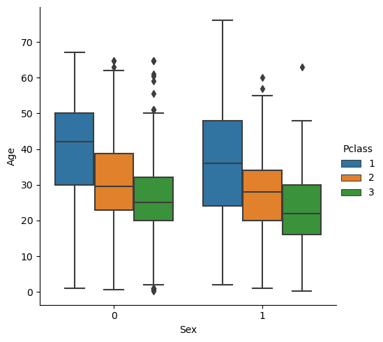

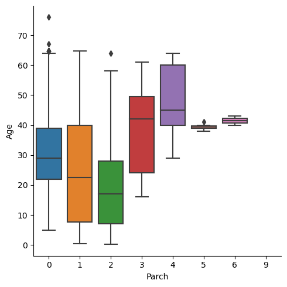

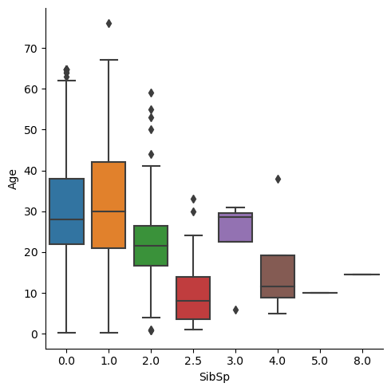

```python
sns.catplot(y = 'Age', x = 'Sex', hue = 'Pclass', kind = 'box', data = combined)
sns.catplot(y = 'Age', x = 'Parch', kind = 'box', data = combined)
sns.catplot(y = 'Age', x = 'SibSp', kind = 'box', data = combined)
plt.show()
```

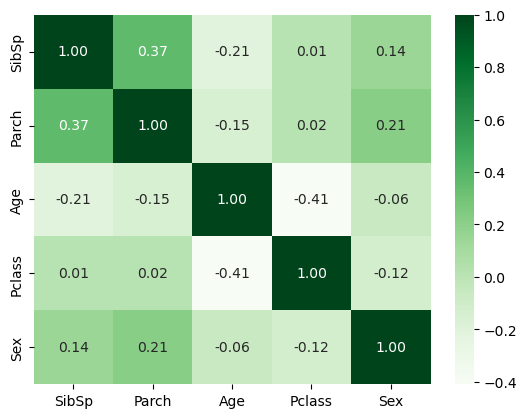

```python
sns.heatmap(combined[['SibSp', 'Parch', 'Age','Pclass','Sex']].corr(), annot = True, fmt = '.2f', cmap = 'Greens')
```

Age is not correlated with Sex but is negatively correlated with SibSp, Parch and Pclass.

```python
# Check number of missing ages

age_nan_indices = list(combined[combined['Age'].isnull()].index)
len(age_nan_indices)
```

```
263
```

Loop through each missing age in the list to locate the rows that have the same SibSp, Parch and PClass values and fill the missing age with the median of those rows. If rows are not found, simply fill the missing age with the median of the entire Age column.

```python
# Loop through list and impute missing ages

for index in age_nan_indices:
    median_age = combined['Age'].median()
    predict_age = combined['Age'][(combined['SibSp'] == combined.iloc[index]['SibSp'])
                                 & (combined['Parch'] == combined.iloc[index]['Parch'])
                                 & (combined['Pclass'] == combined.iloc[index]["Pclass"])].median()
    if np.isnan(predict_age):
        combined['Age'].iloc[index] = median_age
    else:
        combined['Age'].iloc[index] = predict_age
```

```python
# Make sure there is no more missing ages

combined['Age'].isnull().sum()
```

```
0
```

### 5.2 Data transformation

Recall that our passenger fare column has a very high positive skewness. Therefore, we will apply a log transformation to address this issue.

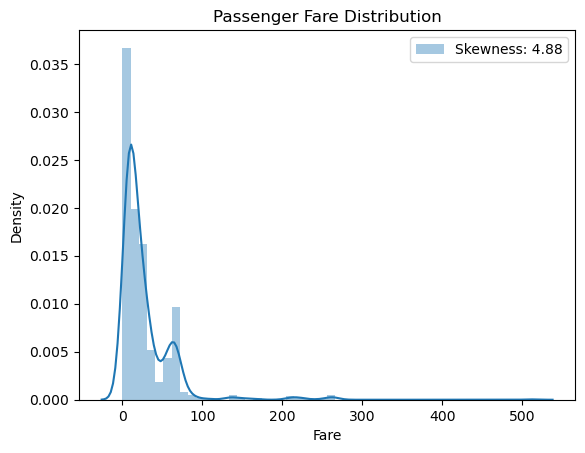

```python
# Passenger fare distribution

sns.distplot(combined['Fare'], label = 'Skewness: %.2f'%(combined['Fare'].skew()))
plt.legend(loc = 'best')
plt.title('Passenger Fare Distribution')
```

```python
# Apply log transformation to Fare column to reduce skewness

combined['Fare'] = combined['Fare'].map(lambda x: np.log(x) if x > 0 else 0)
```

[figure not shown]

```python
# Passenger fare distribution after log transformation

sns.distplot(combined['Fare'], label = 'Skewness: %.2f'%(combined['Fare'].skew()))
plt.legend(loc = 'best')
plt.title('Passenger Fare Distribution After Log Transformation')
```

### 5.3 Feature engineering

Feature engineering is arguably the most important art in machine learning. It is the process of creating new features from existing features to better represent the underlying problem to the predictive models resulting in improved model accuracy on unseen data.

### 5.3.1 Title

```python
combined.head()
```

[output not shown]

```python
# Get title from name

combined['Title'] = [name.split(',')[1].split('.')[0].strip() for name in combined['Name']]
combined[['Name', 'Title']].head()
```

|  | Name | Title |
| --- | --- | --- |
| 0 | Braund, Mr. Owen Harris | Mr |
| 1 | Cumings, Mrs. John Bradley (Florence Briggs Th... | Mrs |
| 2 | Heikkinen, Miss. Laina | Miss |
| 3 | Futrelle, Mrs. Jacques Heath (Lily May Peel) | Mrs |
| 4 | Allen, Mr. William Henry | Mr |

```python
# Value counts of Title

combined['Title'].value_counts()
```

```
Title
Mr              757
Miss            260
Mrs             197
Master           61
Rev               8
Dr                8
Col               4
Mlle              2
Major             2
Ms                2
Lady              1
Sir               1
Mme               1
Don               1
Capt              1
the Countess      1
Jonkheer          1
Dona              1
Name: count, dtype: int64
```

```python
# Number of unique Title

combined['Title'].nunique()
```

```
18
```

```python
# Simplify title

combined['Title'] = combined['Title'].replace(['Dr', 'Rev', 'Col', 'Major', 'Lady', 'Jonkheer', 'Don', 'Capt', 'the Countess',
                                             'Sir', 'Dona'], 'Rare')
combined['Title'] = combined['Title'].replace(['Mlle', 'Ms'], 'Miss')
combined['Title'] = combined['Title'].replace('Mme', 'Mrs')
```

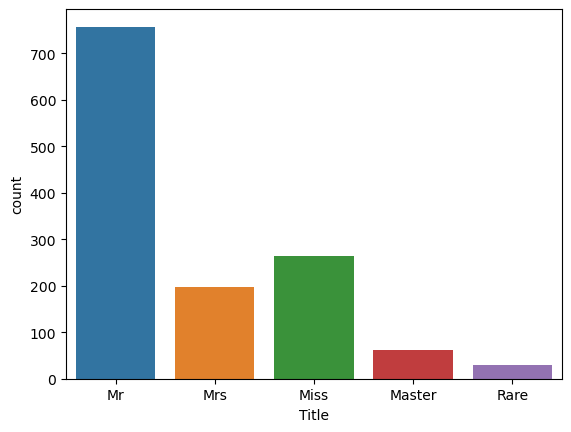

```python
sns.countplot(x=combined['Title'])
plt.show()
```

```python
# Mean of survival by name title

combined[['Title', 'Survived']].groupby(['Title'], as_index = False).mean().sort_values(by = 'Survived', ascending = False)
```

|  | Title | Survived |
| --- | --- | --- |
| 3 | Mrs | 0.793651 |
| 1 | Miss | 0.702703 |
| 0 | Master | 0.575000 |
| 4 | Rare | 0.347826 |
| 2 | Mr | 0.156673 |

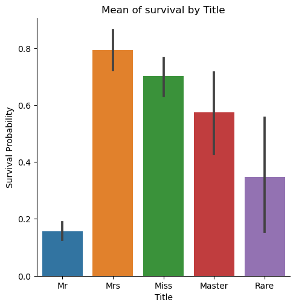

```python
sns.catplot(x = 'Title', y = 'Survived', data = combined, kind = 'bar')
plt.ylabel('Survival Probability')
plt.title('Mean of survival by Title')
plt.show()
```

### 5.3.2 IsAlone

As we observed from our data visualization being alone on the titanic had a disadvantage when it came to survival: Next we will create a feature IsAlone which depends on the number of family members that can be calculated from the Parch and SibSp columns

```python
# Calculate family size from SibSp and Parch

combined['Family_Size']=combined['SibSp']+combined['Parch']
combined[['SibSp', 'Parch', 'Family_Size']].head(10)
```

|  | SibSp | Parch | Family_Size |
| --- | --- | --- | --- |
| 0 | 1.0 | 0 | 1.0 |
| 1 | 1.0 | 0 | 1.0 |
| 2 | 0.0 | 0 | 0.0 |
| 3 | 1.0 | 0 | 1.0 |
| 4 | 0.0 | 0 | 0.0 |
| 5 | 0.0 | 0 | 0.0 |
| 6 | 0.0 | 0 | 0.0 |
| 7 | 2.5 | 1 | 3.5 |
| 8 | 0.0 | 2 | 2.0 |
| 9 | 1.0 | 0 | 1.0 |

```python
# Create IsAlone feature

combined['IsAlone'] = np.where(combined["Family_Size"] > 0, 0,1)
combined.head()
```

|  | PassengerId | Survived | Pclass | Name | Sex | Age | SibSp | Parch | Fare | Embarked | Title | Family_Size | IsAlone |
| --- | --- | --- | --- | --- | --- | --- | --- | --- | --- | --- | --- | --- | --- |
| 0 | 1 | 0.0 | 3 | Braund, Mr. Owen Harris | 0 | 22.0 | 1.0 | 0 | 7.2500 | S | Mr | 1.0 | 0 |
| 1 | 2 | 1.0 | 1 | Cumings, Mrs. John Bradley (Florence Briggs Th... | 1 | 38.0 | 1.0 | 0 | 65.6344 | C | Mrs | 1.0 | 0 |
| 2 | 3 | 1.0 | 3 | Heikkinen, Miss. Laina | 1 | 26.0 | 0.0 | 0 | 7.9250 | S | Miss | 0.0 | 1 |
| 3 | 4 | 1.0 | 1 | Futrelle, Mrs. Jacques Heath (Lily May Peel) | 1 | 35.0 | 1.0 | 0 | 53.1000 | S | Mrs | 1.0 | 0 |
| 4 | 5 | 0.0 | 3 | Allen, Mr. William Henry | 0 | 35.0 | 0.0 | 0 | 8.0500 | S | Mr | 0.0 | 1 |

```python
# Mean of survival by IsAlone

combined[['IsAlone', 'Survived']].groupby('IsAlone', as_index = False).mean().sort_values(by = 'Survived', ascending = False)
```

|  | IsAlone | Survived |
| --- | --- | --- |
| 0 | 0 | 0.505650 |
| 1 | 1 | 0.303538 |

```python
# Drop Family_Size column

combined = combined.drop(['Name','SibSp','Parch','Family_Size'], axis = 1)
combined.head()
```

|  | PassengerId | Survived | Pclass | Sex | Age | Fare | Embarked | Title | IsAlone |
| --- | --- | --- | --- | --- | --- | --- | --- | --- | --- |
| 0 | 1 | 0.0 | 3 | 0 | 22.0 | 7.2500 | S | Mr | 0 |
| 1 | 2 | 1.0 | 1 | 1 | 38.0 | 65.6344 | C | Mrs | 0 |
| 2 | 3 | 1.0 | 3 | 1 | 26.0 | 7.9250 | S | Miss | 1 |
| 3 | 4 | 1.0 | 1 | 1 | 35.0 | 53.1000 | S | Mrs | 0 |
| 4 | 5 | 0.0 | 3 | 0 | 35.0 | 8.0500 | S | Mr | 1 |

```python
# Create age bands and compute mean of survival by age bands

combined['AgeBand'] = pd.cut(combined['Age'], 5)
combined[['AgeBand', 'Survived']].groupby('AgeBand', as_index=False).mean().sort_values(by = 'AgeBand')
```

|  | AgeBand | Survived |
| --- | --- | --- |
| 0 | (0.0942, 15.336] | 0.510417 |
| 1 | (15.336, 30.502] | 0.335498 |
| 2 | (30.502, 45.668] | 0.431034 |
| 3 | (45.668, 60.834] | 0.417722 |
| 4 | (60.834, 76.0] | 0.227273 |

```python
# Assign ordinals to each age band

combined.loc[combined['Age'] <= 16.136, 'Age'] = 0
combined.loc[(combined['Age'] > 16.136) & (combined['Age'] <= 32.102), 'Age'] = 1
combined.loc[(combined['Age'] > 32.102) & (combined['Age'] <= 48.068), 'Age'] = 2
combined.loc[(combined['Age'] > 48.068) & (combined['Age'] <= 64.034), 'Age'] = 3
combined.loc[combined['Age'] > 64.034 , 'Age'] = 48.068
```

```python
combined.head()
```

|  | PassengerId | Survived | Pclass | Sex | Age | Fare | Embarked | Title | IsAlone | AgeBand |
| --- | --- | --- | --- | --- | --- | --- | --- | --- | --- | --- |
| 0 | 1 | 0.0 | 3 | 0 | 1.0 | 7.2500 | S | Mr | 0 | (15.336, 30.502] |
| 1 | 2 | 1.0 | 1 | 1 | 2.0 | 65.6344 | C | Mrs | 0 | (30.502, 45.668] |
| 2 | 3 | 1.0 | 3 | 1 | 1.0 | 7.9250 | S | Miss | 1 | (15.336, 30.502] |
| 3 | 4 | 1.0 | 1 | 1 | 2.0 | 53.1000 | S | Mrs | 0 | (30.502, 45.668] |
| 4 | 5 | 0.0 | 3 | 0 | 2.0 | 8.0500 | S | Mr | 1 | (30.502, 45.668] |

```python
# Drop age band feature

combined = combined.drop('AgeBand', axis = 1)
```

```python
# Age and Pclass data types

combined[['Age', 'Pclass']].dtypes
```

```
Age       float64
Pclass      int64
dtype: object
```

```python
# Convert ordinal Age into integer

combined['Age'] = combined['Age'].astype('int')
combined['Age'].dtype
```

```
dtype('int32')
```

```python
combined.head()
```

|  | PassengerId | Survived | Pclass | Sex | Age | Fare | Embarked | Title | IsAlone |
| --- | --- | --- | --- | --- | --- | --- | --- | --- | --- |
| 0 | 1 | 0.0 | 3 | 0 | 1 | 7.2500 | S | Mr | 0 |
| 1 | 2 | 1.0 | 1 | 1 | 2 | 65.6344 | C | Mrs | 0 |
| 2 | 3 | 1.0 | 3 | 1 | 1 | 7.9250 | S | Miss | 1 |
| 3 | 4 | 1.0 | 1 | 1 | 2 | 53.1000 | S | Mrs | 0 |
| 4 | 5 | 0.0 | 3 | 0 | 2 | 8.0500 | S | Mr | 1 |

### 5.4 Feature encoding

Machine learning models require all input and output variables to be numeric. Therefore, we need to encode all of our categorical data before we can fit the models to our data.

Previously, we have encoded the sex column such that 0 = male and 1 = female. We need to repeat this process for Title and Embarked. In addition, similar to the age column, I will also transform Fare into an ordinal variable rather than a continuous variable.

```python
# Encode Title and Embarked feature

combined = pd.get_dummies(combined, columns = ['Title'])
combined = pd.get_dummies(combined, columns = ['Embarked'], prefix = 'Em')
combined[['Title_Master','Title_Miss','Title_Mr','Title_Mrs','Title_Rare','Em_C','Em_Q','Em_S']]=combined[['Title_Master','Title_Miss','Title_Mr','Title_Mrs','Title_Rare','Em_C','Em_Q','Em_S']].astype('int')
combined.head()
```

|  | PassengerId | Survived | Pclass | Sex | Age | Fare | IsAlone | Title_Master | Title_Miss | Title_Mr | Title_Mrs | Title_Rare | Em_C | Em_Q | Em_S |
| --- | --- | --- | --- | --- | --- | --- | --- | --- | --- | --- | --- | --- | --- | --- | --- |
| 0 | 1 | 0.0 | 3 | 0 | 1 | 7.2500 | 0 | 0 | 0 | 1 | 0 | 0 | 0 | 0 | 1 |
| 1 | 2 | 1.0 | 1 | 1 | 2 | 65.6344 | 0 | 0 | 0 | 0 | 1 | 0 | 1 | 0 | 0 |
| 2 | 3 | 1.0 | 3 | 1 | 1 | 7.9250 | 1 | 0 | 1 | 0 | 0 | 0 | 0 | 0 | 1 |
| 3 | 4 | 1.0 | 1 | 1 | 2 | 53.1000 | 0 | 0 | 0 | 0 | 1 | 0 | 0 | 0 | 1 |
| 4 | 5 | 0.0 | 3 | 0 | 2 | 8.0500 | 1 | 0 | 0 | 1 | 0 | 0 | 0 | 0 | 1 |

```python
# Divide Fare into four bands

combined['FareBand'] = pd.cut(combined['Fare'], 4)
combined[['FareBand', 'Survived']].groupby(['FareBand'], as_index=False).mean().sort_values(by = 'FareBand')
```

|  | FareBand | Survived |
| --- | --- | --- |
| 0 | (-0.512, 128.082] | 0.383838 |
| 1 | (128.082, 256.165] | NaN |
| 2 | (256.165, 384.247] | NaN |
| 3 | (384.247, 512.329] | NaN |

```python
# Assign ordinal to each fare band

combined.loc[combined['Fare'] <= 1.56, 'Fare'] = 0
combined.loc[(combined['Fare'] > 1.56) & (combined['Fare'] <= 3.119), 'Fare'] = 1
combined.loc[(combined['Fare'] > 3.119) & (combined['Fare'] <= 4.679), 'Fare'] = 2
combined.loc[combined['Fare'] > 4.679, 'Fare'] = 3
```

```python
# Convert Fare into integer

combined['Fare'] = combined['Fare'].astype('int')
```

```python
combined['Fare'].dtype
```

```
dtype('int32')
```

```python
# Drop FareBand feature

combined = combined.drop('FareBand', axis = 1)
```

```python
combined.head()
```

|  | PassengerId | Survived | Pclass | Sex | Age | Fare | IsAlone | Title_Master | Title_Miss | Title_Mr | Title_Mrs | Title_Rare | Em_C | Em_Q | Em_S |
| --- | --- | --- | --- | --- | --- | --- | --- | --- | --- | --- | --- | --- | --- | --- | --- |
| 0 | 1 | 0.0 | 3 | 0 | 1 | 3 | 0 | 0 | 0 | 1 | 0 | 0 | 0 | 0 | 1 |
| 1 | 2 | 1.0 | 1 | 1 | 2 | 3 | 0 | 0 | 0 | 0 | 1 | 0 | 1 | 0 | 0 |
| 2 | 3 | 1.0 | 3 | 1 | 1 | 3 | 1 | 0 | 1 | 0 | 0 | 0 | 0 | 0 | 1 |
| 3 | 4 | 1.0 | 1 | 1 | 2 | 3 | 0 | 0 | 0 | 0 | 1 | 0 | 0 | 0 | 1 |
| 4 | 5 | 0.0 | 3 | 0 | 2 | 3 | 1 | 0 | 0 | 1 | 0 | 0 | 0 | 0 | 1 |

```python
# Separate training and test set from the combined dataframe

train = combined[:len(train)]
test = combined[len(train):]
```

```python
train.shape
```

[output not shown]

```python
test.shape
```

[output not shown]

```python
train.head()
```

|  | PassengerId | Survived | Pclass | Sex | Age | Fare | IsAlone | Title_Master | Title_Miss | Title_Mr | Title_Mrs | Title_Rare | Em_C | Em_Q | Em_S |
| --- | --- | --- | --- | --- | --- | --- | --- | --- | --- | --- | --- | --- | --- | --- | --- |
| 0 | 1 | 0.0 | 3 | 0 | 1 | 3 | 0 | 0 | 0 | 1 | 0 | 0 | 0 | 0 | 1 |
| 1 | 2 | 1.0 | 1 | 1 | 2 | 3 | 0 | 0 | 0 | 0 | 1 | 0 | 1 | 0 | 0 |
| 2 | 3 | 1.0 | 3 | 1 | 1 | 3 | 1 | 0 | 1 | 0 | 0 | 0 | 0 | 0 | 1 |
| 3 | 4 | 1.0 | 1 | 1 | 2 | 3 | 0 | 0 | 0 | 0 | 1 | 0 | 0 | 0 | 1 |
| 4 | 5 | 0.0 | 3 | 0 | 2 | 3 | 1 | 0 | 0 | 1 | 0 | 0 | 0 | 0 | 1 |

```python
# Drop passenger ID column from and training set

train = train.drop('PassengerId', axis = 1)
train.head()
```

|  | Survived | Pclass | Sex | Age | Fare | IsAlone | Title_Master | Title_Miss | Title_Mr | Title_Mrs | Title_Rare | Em_C | Em_Q | Em_S |
| --- | --- | --- | --- | --- | --- | --- | --- | --- | --- | --- | --- | --- | --- | --- |
| 0 | 0.0 | 3 | 0 | 1 | 3 | 0 | 0 | 0 | 1 | 0 | 0 | 0 | 0 | 1 |
| 1 | 1.0 | 1 | 1 | 2 | 3 | 0 | 0 | 0 | 0 | 1 | 0 | 1 | 0 | 0 |
| 2 | 1.0 | 3 | 1 | 1 | 3 | 1 | 0 | 1 | 0 | 0 | 0 | 0 | 0 | 1 |
| 3 | 1.0 | 1 | 1 | 2 | 3 | 0 | 0 | 0 | 0 | 1 | 0 | 0 | 0 | 1 |
| 4 | 0.0 | 3 | 0 | 2 | 3 | 1 | 0 | 0 | 1 | 0 | 0 | 0 | 0 | 1 |

```python
# Convert survived back to integer in the training set

train['Survived'] = train['Survived'].astype('int')
train.head()
```

|  | Survived | Pclass | Sex | Age | Fare | IsAlone | Title_Master | Title_Miss | Title_Mr | Title_Mrs | Title_Rare | Em_C | Em_Q | Em_S |
| --- | --- | --- | --- | --- | --- | --- | --- | --- | --- | --- | --- | --- | --- | --- |
| 0 | 0 | 3 | 0 | 1 | 3 | 0 | 0 | 0 | 1 | 0 | 0 | 0 | 0 | 1 |
| 1 | 1 | 1 | 1 | 2 | 3 | 0 | 0 | 0 | 0 | 1 | 0 | 1 | 0 | 0 |
| 2 | 1 | 3 | 1 | 1 | 3 | 1 | 0 | 1 | 0 | 0 | 0 | 0 | 0 | 1 |
| 3 | 1 | 1 | 1 | 2 | 3 | 0 | 0 | 0 | 0 | 1 | 0 | 0 | 0 | 1 |
| 4 | 0 | 3 | 0 | 2 | 3 | 1 | 0 | 0 | 1 | 0 | 0 | 0 | 0 | 1 |

```python
test.head()
```

|  | PassengerId | Survived | Pclass | Sex | Age | Fare | IsAlone | Title_Master | Title_Miss | Title_Mr | Title_Mrs | Title_Rare | Em_C | Em_Q | Em_S |
| --- | --- | --- | --- | --- | --- | --- | --- | --- | --- | --- | --- | --- | --- | --- | --- |
| 891 | 892 | NaN | 3 | 0 | 2 | 3 | 1 | 0 | 0 | 1 | 0 | 0 | 0 | 1 | 0 |
| 892 | 893 | NaN | 3 | 1 | 2 | 3 | 0 | 0 | 0 | 0 | 1 | 0 | 0 | 0 | 1 |
| 893 | 894 | NaN | 2 | 0 | 3 | 3 | 1 | 0 | 0 | 1 | 0 | 0 | 0 | 1 | 0 |
| 894 | 895 | NaN | 3 | 0 | 1 | 3 | 1 | 0 | 0 | 1 | 0 | 0 | 0 | 0 | 1 |
| 895 | 896 | NaN | 3 | 1 | 1 | 3 | 0 | 0 | 0 | 0 | 1 | 0 | 0 | 0 | 1 |

```python
# Drop passenger survived column from test set

test = test.drop('Survived', axis = 1)
test.head()
```

|  | PassengerId | Pclass | Sex | Age | Fare | IsAlone | Title_Master | Title_Miss | Title_Mr | Title_Mrs | Title_Rare | Em_C | Em_Q | Em_S |
| --- | --- | --- | --- | --- | --- | --- | --- | --- | --- | --- | --- | --- | --- | --- |
| 891 | 892 | 3 | 0 | 2 | 3 | 1 | 0 | 0 | 1 | 0 | 0 | 0 | 1 | 0 |
| 892 | 893 | 3 | 1 | 2 | 3 | 0 | 0 | 0 | 0 | 1 | 0 | 0 | 0 | 1 |
| 893 | 894 | 2 | 0 | 3 | 3 | 1 | 0 | 0 | 1 | 0 | 0 | 0 | 1 | 0 |
| 894 | 895 | 3 | 0 | 1 | 3 | 1 | 0 | 0 | 1 | 0 | 0 | 0 | 0 | 1 |
| 895 | 896 | 3 | 1 | 1 | 3 | 0 | 0 | 0 | 0 | 1 | 0 | 0 | 0 | 1 |

Our dataframes are ready for modelling!

## 6. Modelling

```python
X_train = train.drop('Survived', axis = 1)
Y_train = train['Survived']
X_test = test.drop('PassengerId', axis = 1).copy()

print("X_train shape: ", X_train.shape)
print("Y_train shape: ", Y_train.shape)
print("X_test shape: ", X_test.shape)
```

```
X_train shape:  (891, 13)
Y_train shape:  (891,)
X_test shape:  (418, 13)
```

### Decision Tree

```python
decision_tree = DecisionTreeClassifier()
decision_tree.fit(X_train, Y_train)
```

```
DecisionTreeClassifier()
```

```python
# prediction on training data

prediction_on_training_data = decision_tree.predict(X_train)
accuracy_on_training_data = accuracy_score(Y_train, prediction_on_training_data)
```

```python
print('Accuracy on training data : ', accuracy_on_training_data*100)
```

```
Accuracy on training data :  84.28731762065095
```

```python
Y_pred_DT = decision_tree.predict(X_test)
```

```python
Y_pred_DT
```

```
array([0, 0, 0, 0, 1, 0, 1, 0, 1, 0, 0, 0, 1, 0, 1, 1, 0, 0, 0, 0, 0, 0,
       1, 0, 1, 0, 1, 0, 0, 0, 0, 0, 0, 0, 0, 0, 0, 0, 0, 0, 0, 0, 0, 1,
       1, 0, 0, 0, 0, 0, 0, 0, 1, 1, 0, 0, 0, 0, 0, 1, 0, 0, 0, 1, 1, 1,
       1, 0, 0, 1, 1, 0, 0, 0, 1, 0, 0, 1, 0, 1, 1, 0, 0, 0, 0, 0, 1, 0,
       1, 1, 1, 0, 1, 0, 0, 0, 1, 0, 0, 0, 1, 0, 0, 0, 1, 0, 0, 0, 0, 0,
       0, 1, 1, 1, 1, 0, 0, 0, 0, 1, 1, 0, 1, 0, 0, 0, 0, 1, 0, 0, 0, 1,
       1, 0, 0, 0, 0, 0, 0, 0, 0, 1, 0, 0, 0, 0, 0, 0, 0, 0, 1, 0, 0, 0,
       0, 0, 1, 0, 0, 1, 1, 1, 1, 0, 0, 1, 0, 0, 1, 0, 0, 0, 0, 0, 0, 1,
       1, 0, 1, 1, 0, 1, 1, 0, 1, 0, 1, 0, 0, 0, 0, 0, 0, 0, 1, 0, 1, 0,
       0, 0, 1, 0, 0, 1, 0, 0, 0, 0, 1, 0, 0, 0, 0, 1, 0, 0, 1, 0, 1, 0,
       1, 0, 1, 0, 0, 1, 0, 1, 0, 0, 0, 1, 0, 0, 1, 0, 0, 0, 1, 1, 0, 1,
       1, 0, 0, 0, 1, 0, 1, 1, 1, 0, 0, 0, 0, 0, 0, 0, 1, 0, 0, 0, 1, 0,
       0, 0, 0, 0, 0, 0, 0, 0, 1, 1, 0, 1, 0, 0, 0, 0, 0, 0, 1, 1, 0, 0,
       0, 0, 0, 0, 0, 1, 0, 1, 0, 0, 1, 0, 0, 0, 0, 0, 0, 0, 1, 1, 0, 0,
       0, 0, 0, 0, 0, 0, 0, 1, 0, 0, 0, 0, 0, 0, 0, 0, 1, 0, 1, 0, 0, 0,
       1, 0, 0, 1, 0, 0, 0, 0, 0, 1, 0, 0, 0, 1, 0, 0, 0, 0, 0, 1, 1, 0,
       0, 0, 0, 0, 1, 0, 0, 1, 0, 1, 1, 0, 1, 1, 0, 0, 1, 0, 0, 1, 0, 0,
       1, 1, 0, 0, 0, 0, 0, 0, 0, 1, 0, 1, 0, 0, 0, 0, 0, 1, 0, 0, 0, 1,
       0, 1, 0, 0, 1, 0, 1, 0, 1, 0, 0, 0, 1, 0, 1, 1, 0, 0, 1, 0, 0, 1])
```

```python
len(Y_pred_DT)
```

```
418
```

### Random forest

```python
random_forest = RandomForestClassifier(n_estimators = 100)
random_forest.fit(X_train, Y_train)
```

```
RandomForestClassifier()
```

```python
prediction_on_training_data = random_forest.predict(X_train)
accuracy_on_training_data = accuracy_score(Y_train, prediction_on_training_data)
```

```python
print('Accuracy on training data : ', accuracy_on_training_data*100)
```

```
Accuracy on training data :  84.28731762065095
```

```python
Y_pred_RF = random_forest.predict(X_test)
```

```python
Y_pred_RF
```

```
array([0, 0, 0, 0, 1, 0, 1, 0, 1, 0, 0, 0, 1, 0, 1, 1, 0, 0, 0, 1, 0, 0,
       1, 1, 1, 0, 1, 0, 0, 0, 0, 0, 0, 0, 1, 0, 0, 0, 0, 0, 0, 0, 0, 1,
       1, 0, 0, 0, 1, 0, 0, 0, 1, 1, 0, 0, 0, 0, 0, 1, 0, 0, 0, 1, 1, 1,
       1, 0, 0, 1, 1, 0, 0, 0, 1, 0, 0, 1, 0, 1, 1, 0, 0, 0, 0, 0, 1, 0,
       1, 1, 1, 0, 1, 0, 0, 0, 1, 0, 0, 0, 1, 0, 0, 0, 1, 0, 0, 0, 0, 0,
       0, 1, 1, 1, 1, 0, 0, 0, 0, 1, 1, 0, 1, 0, 0, 0, 0, 1, 0, 0, 0, 1,
       1, 0, 0, 0, 0, 0, 0, 0, 0, 1, 0, 0, 0, 0, 0, 0, 0, 0, 1, 0, 0, 0,
       0, 0, 1, 0, 0, 1, 1, 1, 1, 0, 0, 1, 0, 0, 1, 0, 0, 0, 0, 0, 0, 1,
       1, 0, 1, 1, 0, 1, 1, 0, 1, 0, 1, 0, 0, 0, 0, 0, 0, 0, 1, 0, 1, 0,
       0, 0, 1, 0, 1, 1, 0, 0, 1, 0, 1, 0, 0, 0, 0, 1, 0, 0, 1, 0, 1, 0,
       1, 0, 1, 0, 1, 1, 0, 1, 0, 0, 0, 1, 0, 0, 1, 0, 0, 0, 1, 1, 1, 1,
       1, 0, 0, 0, 1, 0, 1, 1, 1, 0, 1, 0, 0, 0, 0, 0, 1, 0, 0, 0, 1, 0,
       0, 0, 0, 0, 0, 0, 0, 0, 1, 1, 0, 1, 0, 0, 0, 0, 0, 0, 1, 1, 0, 0,
       0, 0, 0, 0, 0, 1, 0, 1, 0, 0, 1, 0, 0, 0, 0, 0, 0, 0, 1, 1, 0, 0,
       0, 0, 0, 0, 0, 1, 1, 1, 0, 0, 0, 0, 0, 0, 0, 0, 1, 0, 1, 0, 0, 0,
       1, 0, 0, 1, 0, 0, 0, 0, 0, 1, 0, 0, 0, 1, 0, 0, 0, 1, 0, 1, 1, 0,
       0, 0, 0, 0, 1, 0, 0, 1, 0, 1, 1, 0, 1, 1, 0, 0, 1, 0, 0, 1, 0, 0,
       1, 1, 0, 0, 0, 0, 0, 0, 0, 1, 0, 1, 0, 0, 0, 0, 0, 1, 0, 0, 0, 1,
       0, 1, 0, 0, 1, 0, 1, 0, 1, 0, 0, 0, 1, 0, 1, 1, 0, 0, 1, 0, 0, 1])
```

```python
len(Y_pred_RF)
```

```
418
```

## 7. Preparing data for submission

```python
# Create submission dataframe

submitt = pd.DataFrame({'PassengerId': test['PassengerId'], 'Survived': Y_pred_RF})
submitt.head()
```

|  | PassengerId | Survived |
| --- | --- | --- |
| 891 | 892 | 0 |
| 892 | 893 | 0 |
| 893 | 894 | 0 |
| 894 | 895 | 0 |
| 895 | 896 | 1 |

```python
submitt.shape
```

```
(418, 2)
```

Our dataframe is ready for submission!

```python
# Create and save csv file

submitt.to_csv("Submission.csv", index = False)
```